# Housing Price Prediction

## Problem Statement

Housing is an important investment tool in the toolkit of any investors. However, with a multiplicity of factors when choosing a house, it is often difficult to pinpoint the most important factors influencing sale price of houses.

To help investors and homeowners of Ames pick the best house and the most worthwhile upgrades in order to optmise sale price, we will build a predictor which predicts the sale price base on various aspects of a house, from floor area to roofing type, before identifying some of the most important factors which helps owners maximise the sale value of their house.

**Role taken: Advisor to potential property investors and homeowners**

## Background

Ames is a city located in in Story County, Iowa, USA. With a population of 66,427 in 2020, it is only the 6th largest city in Iowa, and considered a small size city. Ames has a booming economy, in 2015, it was ranked one of the top 15 "Cities That Have Done the Best Since the Recession" by Bloomberg Businessweek [(Source)](https://www.bloomberg.com/news/articles/2015-06-22/here-are-the-15-cities-that-have-done-the-best-and-the-worst-since-the-recession), it also has one of the lowest unemployment rates in the united states.

## Datasets

We will use the dataset containing housing data from Ames, Iowa, United States. The dataset provides info used in assessing values for residential properties sold from 2006 to 2010, compiled by the Ames Assessor’s Office.

The dataset contains 2929 observations and 81 features. It is further divided into training and test sets for the purpose of model training.

**training set**

- `train.csv`: 2051 observations and 81 features, including 80 predictors of sale price and 1 response feature containing the corresponding sale price of properties

**Test set**

- `test.csv`: 878 observations and 80 features, with the sale price feature removed

## Data Dictionary

| Feature Label | Description | Categories | Aspect of house | Data Type |
| --- | --- | --- | --- | --- |
| Id | Unique ID | None | Administrative | None |
| PID | Parcel Identification Number assigned to each property within the Ames | None | Unrelated | None |
| MS SubClass | The building class | 20: 1-STORY 1946 & NEWER ALL STYLES / 30: 1-STORY 1945 & OLDER / 40: 1-STORY W/FINISHED ATTIC ALL AGES / 45: 1-1/2 STORY - UNFINISHED ALL AGES / 50: 1-1/2 STORY FINISHED ALL AGES / 60: 2-STORY 1946 & … | Type | Nominal |
| MS Zoning | Identifies the general zoning classification of the sale | A: Agriculture / C: Commercial / FV: Floating Village Residential / I: Industrial / RH: Residential High Density / RL: Residential Low Density / RP: Residential Low Density Park / RM: Residential Medi… | Administrative | Nominal |
| Lot Frontage | Linear feet of street connected to property | None | Environment | Numeric |
| Lot Area | Lot size in square feet | None | Land | Numeric |
| Street | Type of road access to property | Grvl: Gravel / Pave: Paved | Environment | Nominal |
| Alley | Type of alley access to property | Grvl: Gravel / Pave: Paved / NA: No alley access | Environment | Nominal |
| Lot Shape | General shape of property | Reg: Regular / IR1: Slightly irregular / IR2: Moderately Irregular / IR3: Irregular | Land | Nominal |
| Land Contour | Flatness of the property | Lvl: Near Flat/Level / Bnk: Banked - Quick and significant rise from street grade to building / HLS: Hillside - Significant slope from side to side / Low Depression | Land | Nominal |
| Utilities | Type of utilities available | AllPub: All public Utilities (E,G,W,& S) / NoSewr: Electricity, Gas, and Water (Septic Tank) / NoSeWa: Electricity and Gas Only / ELO: Electricity only | Utility | Nominal |
| Lot Config | Lot configuration | Inside: Inside lot / Corner: Corner lot / CulDSac: Cul-de-sac / FR2: Frontage on 2 sides of property / FR3: Frontage on 3 sides of property | Environment | Nominal |
| Land Slope | Slope of property | Gtl: Gentle slope / Mod: Moderate Slope / Sev: Severe Slope | Land | Nominal |
| Neighborhood | Physical locations within Ames city limit | Value represents unique neighbourhoods in Ames | Environment | Nominal |
| Condition 1 | Proximity to main road or railroad | Artery: Adjacent to arterial street / Feedr: Adjacent to feeder street / Norm: Normal / RRNn: Within 200' of North-South Railroad / RRAn: Adjacent to North-South Railroad / PosN: Near positive off-sit… | Environment | Nominal |
| Condition 2 | Proximity to main road or railroad (if a second is present) | Same as Condition 1 | Environment | Nominal |
| Bldg Type | Type of dwelling | 1Fam: Single-family Detached / 2FmCon: Two-family Conversion; originally built as one-family dwelling / Duplx: Duplex / TwnhsE: Townhouse End Unit / TwnhsI: Townhouse Inside Unit | Type | Nominal |
| House Style | Style of dwelling | 1Story: One story / 1.5Fin: One and one-half story: 2nd level finished / 1.5Unf: One and one-half story: 2nd level unfinished / 2Story: Two story / 2.5Fin: Two and one-half story: 2nd level finished /… | Overall | Nominal |
| Overall Qual | Overall material and finish quality | 10 Very Excellent / 9 Excellent / 8 Very Good / 7 Good / 6 Above Average / 5 Average / 4 Below Average / 3 Fair / 2 Poor / 1 Very Poor | Overall | Ordinal |
| Overall Cond | Overall condition rating | Same as Overall Qual | Overall | Ordinal |
| Year Built | Original construction date | None | Age | Numeric |
| Year Remod/Add | Remodel date (same as construction date if no remodeling or additions) | None | Age | Numeric |
| Roof Style | Type of roof | Flat: Flat / Gable: Gable / Gambrel: Gabrel (Barn) / Hip: Hip / Mansard: Mansard / Shed: Shed | Roof | Nominal |
| Roof Matl | Roof material | ClyTile: Clay or Tile / CompShg: Standard (Composite) Shingle / Membran: Membrane / Metal: Metal / Roll: Roll / Tar&Grv: Gravel & Tar / WdShake: Wood Shakes / WdShngl: Wood Shingles | Roof | Nominal |
| Exterior 1st | Exterior covering on house | AsbShng: Asbestos Shingles / AsphShn: Asphalt Shingles / BrkComm: Brick Common / BrkFace: Brick Face / CBlock: Cinder Block / CemntBd: Cement Board / HdBoard: Hard Board / ImStucc: Imitation Stucco / … | Facade | Nominal |
| Exterior 2nd | Exterior covering on house (if more than one material) | Same as Exterior 1st | Facade | Nominal |
| Mas Vnr Type | Masonry veneer type | BrkCmn: Brick Common / BrkFace: Brick Face / Cblock: Cinder Block / None: None / Stone: Stone | Facade | Nominal |
| Mas Vnr Area | Masonry veneer area in square feet | None | Facade | Numeric |
| Exter Qual | Exterior material quality | Ex: Excellent / Gd: Good / TA: Average/Typical / Fa: Fair / Po: Poor | Facade | Ordinal |
| Exter Cond | Present condition of the material on the exterior | Same as Exter Qual | Facade | Ordinal |

[output cut: 51 more lines]

## Methodology

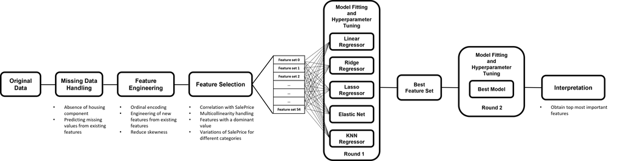

## Model Evaluation

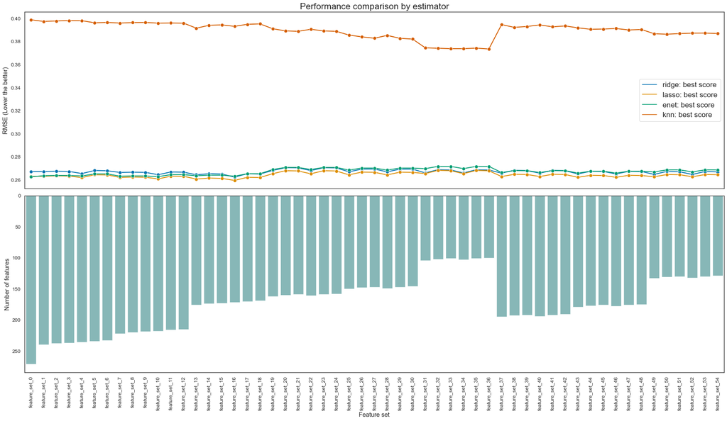

Feature set 16 was able to achieve the best overall score taking into consideration all 5 models. The best model which was able to achieve the lowest Root Mean Squared Error (RMSE) was the Lasso Regression.

Feature set 16 was passed through the best model (Lasso Regressor) for further hyperparameter tuning and below is the scatter plot comparing the predicted house price and actual house price of our model, which indicates a prediction generally closed to the actual value, although there are still rooms for improvement for properties with higher sale price.

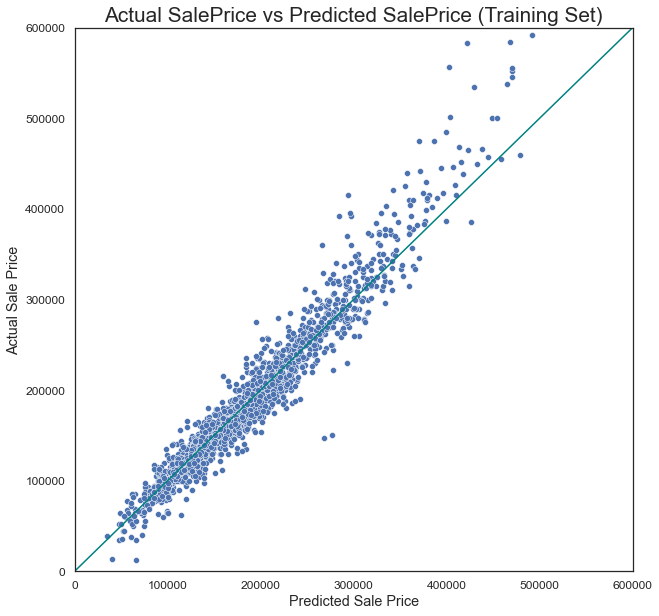

## Interpretation and Recommendations

We then pick out the top 15 most important features having a positive or negative impact on price.

**Most Important Factors Influencing Sale Price**

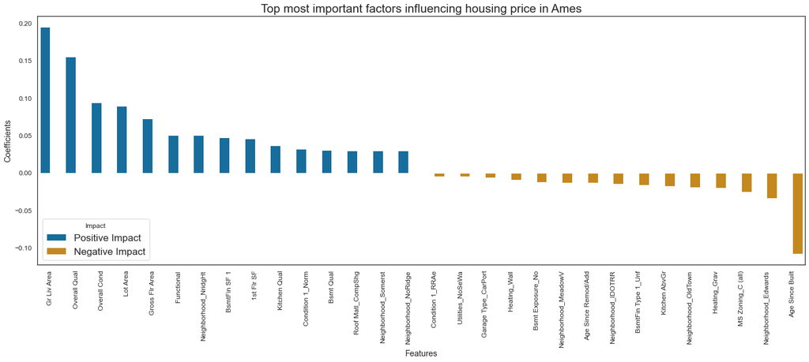

We see that the most important features influencing sale price can be grouped in a few categories:

Features with positive influence on price.

**Area**

- We see that among the most important features influencing sale price are some of the area features, most important among them `Gr Liv Area`, but also `Lot Area`, `BsmtFin SF1` and `1st Flr SF`.

**Quality**

- Other quality measurement such as `Overall Qual`, `Overall Cond`, `Functional`, `Kitchen Qual` and `Basement Qual` may also provide valuable info in helping someone to judge sale price. This points to the importance of perhaps hiring a professional property valuer before making any investment decisions.

**Neighborhoods**

- We have also identified some neighborhoods that has the most potential in terms of getting a good sale price, these includes, `Northridge Heights`, `Somerset` and `Northridge`.

**Proximity**

- The proximity to urban features such as roads or parks do not actually matter that much.

**Roof material**

- It is better to choose Standard (Composite) Shingle as roofing material

Features with negative influence on price.

**House Age**

- The most important feature having a negative impact on price is the `Age Since Built` feature. `Age Since Remod/Add` also have some negative influence on price.

**Neighborhoods**

- You may want to avoid buying properties in neighborhoods such as `Edwards`, `Old Town`, `Iowa DOT and Rail Road` and `Meadow Village`

**Zoning**

- Properties located within commercial zones may not be the best investment

**Heating Type**

- Property with `Gravity Furnace` and `Wall Furnace` generally do not get you a higher price, this is perhaps due to the fact that these are more traditional heating technologies

**Number of Kitchens**

- Quite counter intuitively, the higher the number of kichens, the lower the price, this is perhaps because single family households generally have only need for one kitchens, while a larger number of kitchen generally means that more than 1 household resides in the property

**Basement**

- An `unfinished basement` generally fetches you a lower price, same goes for basements `without exposure`

**Garage type**

- Avoid properties with a `carport` garage, these are sheltered garages attached to a property

**Utilities**

- Avoid properties with `No sewage`

**Proxmity**

- Avoid properties adjacent to the E-W railroad.

## RMSE Score (Kaggle Submission)

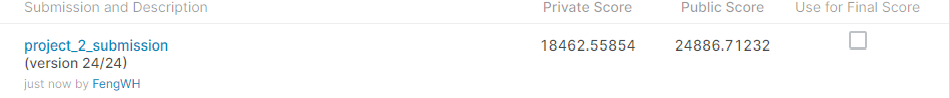